# Project_Tripadvisor

$\Huge{Recommender\ \ system\ \ for\ \ restaurant\ \ choice}$

$\huge{Introduction}$

Where am I going to eat tonight ?

The objective of this project is to get informations on preferences of some customers about different restaurants, and knowing my own opinions about some of these restaurants, to be able to propose a recommendation in order to go and eat at a restaurant that I will really like most surely. To achieve this, I have decided to scrap the website tripadvisor in order to get the ratings of users about restaurants (these ratings go from 1 if they didn't like it to 5 if they loved it), and then to transform these data into a very large and sparse matrix in order to create a recommender system. It means that we will be able throught some machine learning procedures to guess for each user (myself included) the ratings they would have given to restaurants if they went to eat in there, and with this information to propose the top restaurants where they would like to eat, but they don't know it yet.

$\huge{Web scraping}$

In order to build my dataset, I have scraped the 300 first pages of tripadvisor about restaurants in Paris. There are in total more than 500 pages but this gave me enough data and the further you go on those pages, the lesser reviews you get so the last 200 pages are not that usefull for my study. Each page contains 30 restaurants with the links to their own pages, and then when you go to one specific restaurant, you will have at the bottom the first 10 reviews, and the links to the other pages of reviews. Some restaurants have up to 3000 reviews, but most of them only have around 400-500. Needless to say, this procedure took literally for ever (four or five days with two computers), especially because a typo made me do it twice, and also because it seemed like tripadvisor changed some tags during the process, so I had to re-check everything and run it again since it wouldn't work otherwise.

```python
import bs4
from urllib import request

list_url_night_1 = [x*30 for x in range(0,300)]

list_reviews = []
list_names = []
list_restaurant = []

# Do this for the 300 first pages of tripadvisor:
for url_nbr in list_url_night_1:

    # url of a page containing 30 restaurant in tripadvisor: (only the part "url_nbr" changes when going through each page)
    url_tripadvisor = "https://www.tripadvisor.fr/RestaurantSearch-g187147-oa" + str(url_nbr) + "-a_date.2020__2D__01__2D__26-a_people.2-a_time.20%3A00%3A00-a_zur.2020__5F__01__5F__26-Paris_Il.html#EATERY_LIST_CONTENTS"
    request_text = request.urlopen(url_tripadvisor).read()
    page = bs4.BeautifulSoup(request_text, "html.parser")

    # Get for all 30 restaurants the link to the reviews page
    for restaurant in page.findAll("div", {"class": "_1llCuDZj"}):
        try:
            # Skip the first one which is not a restaurant
            if restaurant.get("data-test") != 'SL_list_item':

                # Get the restaurant link
                url_link = restaurant.find("div", {"class": "wQjYiB7z"}).span.a.get("href")
                # Get the restaurant name
                restaurant_name = restaurant.find("div", {"class": "wQjYiB7z"}).span.a.getText()

                # Get the number of pages of reviews of this restaurant
                strainer_nb = bs4.SoupStrainer("div", {"class": "pageNumbers"})
                request_text_np_page = request.urlopen("https://www.tripadvisor.fr" + url_link).read()
                page_review_nb_page = bs4.BeautifulSoup(request_text_np_page, "html.parser", parse_only=strainer_nb)
                n_page_reviews = int(page_review_nb_page.find("div", {"class": "pageNumbers"}).findAll("a")[-1].get("data-page-number"))

                list_page_reviews = [x*10 for x in range(n_page_reviews)]
                # There are 10 reviews per pages
                # Get for all pages of reviews the users and the ratings
                for l_p_r in list_page_reviews:

                    strainer_review = bs4.SoupStrainer("div", {"class": "review-container"})
                    url_link_modified = "-".join(url_link.split("-")[0:4]) + "-or" + str(l_p_r) + "-" + "-".join(url_link.split("-")[4:6])
                    request_text = request.urlopen("https://www.tripadvisor.fr" + url_link_modified).read()
                    page_review = bs4.BeautifulSoup(request_text, "html.parser")
                    # Sometimes a name or a review is missing so we need to check it:
                    if len(page_review.findAll("div", {"class": "info_text pointer_cursor"})) == 10:
                        for review in page_review.findAll("div", {"class": "review-container"}):
                            # name of the restaurant in a list
                            list_restaurant.append(restaurant_name)
                            try:
                                # review in a list
                                list_reviews.append(review.find("div", {"class": "ui_column is-9"}).span.get("class")[1])
                                # name of user in a list
                                list_names.append(review.find("div", {"class": "info_text pointer_cursor"}).div.getText())
                            except:
                                list_reviews.append("NaN")
                                list_names.append("NaN")
                    else:
                        print(None)
        except:
            print(None)

# Export as csv
import pandas as pd
df = pd.DataFrame({"restaurant": list_restaurant, "name":list_names, "review": list_reviews})
df.to_csv("/Users/julienfoenet/Desktop/ENSAE/Machine_Learning_Python/Poject_tripadvisor/dataframe_0_300.csv")
```

$\huge{\text{Machine learning}}$

$\LARGE{\text{Importation}}$

```python
import numpy as np
import pandas as pd
import matplotlib.pyplot as plt
import seaborn as sns
plt.style.use('seaborn-whitegrid')
sns.set()
import glob
import warnings
warnings.filterwarnings('ignore')


all_fileusers = [f for f in glob.glob("/Users/julienfoenet/Desktop/ENSAE/Machine_Learning_Python/Poject_tripadvisor/data/" + "*.{}".format("csv"))]
data = pd.concat([pd.read_csv(f) for f in all_fileusers])

data.head()
```

|  | Unnamed: 0 | name | restaurant | review |
| --- | --- | --- | --- | --- |
| 0 | 0 | Camille D | 2101. L'Enveloppe | bubble_50 |
| 1 | 1 | sak0u | 2101. L'Enveloppe | bubble_50 |
| 2 | 2 | Juedepapaye | 2101. L'Enveloppe | bubble_50 |
| 3 | 3 | agathebp13 | 2101. L'Enveloppe | bubble_50 |
| 4 | 4 | sandrinefomberteau | 2101. L'Enveloppe | bubble_40 |

Our dataframe contains 951210 reviews

```python
print(data.shape)
```

```
(951210, 4)
```

$\LARGE{\text{Feature Engineering}}$

```python
# we notice that there is a useless column, we only want to keep the three we are intersted in
data = data[["name", "restaurant", "review"]]

# we rename the column "name" by "user"
data.rename(columns={"name": "user"}, inplace=True)

# some users gave multiple times the same review to the same restaurant
data.drop_duplicates(inplace=True)

# the name of the users start with numbers, we want to get rid of it
def remove_numbers(s):
    return " ".join(s.split(" ")[1:])
data["restaurant"] = data["restaurant"].apply(remove_numbers)

# the rating are like 'bubble_50' or 'bubble_40' which we want to convert to 5.0 or 4.0
def extract_ratings(s):
    return int(s.split("_")[1]) / 10
data["review"] = data["review"].apply(extract_ratings)

# now that's better
data.head()
```

|  | user | restaurant | review |
| --- | --- | --- | --- |
| 0 | Camille D | L'Enveloppe | 5.0 |
| 1 | sak0u | L'Enveloppe | 5.0 |
| 2 | Juedepapaye | L'Enveloppe | 5.0 |
| 3 | agathebp13 | L'Enveloppe | 5.0 |
| 4 | sandrinefomberteau | L'Enveloppe | 4.0 |

$\LARGE{\text{Data Analysis}}$

We notice that there are a lot more of 5 and 4 ratings than the others, that's not really surprising since most of the people tend to give reviews when they are satisfied more than when they aren't. Aslo we can notice that there is a 0 rating, which we need to remove.

```python
print(data.describe())
print("------------------------")
print(data['review'].value_counts())
```

```
              review
count  932657.000000
mean        4.032223
std         1.146950
min         0.000000
25%         4.000000
50%         4.000000
75%         5.000000
max         5.000000
------------------------
5.0    410074
4.0    307639
3.0    103677
2.0     57458
1.0     53808
0.0         1
Name: review, dtype: int64
```

```python
data = data[data["review"] != 0.0]
```

$\Large{\text{The users}}$

Let's check how many ratings have given each users

```python
data["user"].value_counts()
```

```
Philippe C            597
famousserge           482
HuguesA76             401
TaDaYeah              304
Philippe B            271
                     ...
Spacemontain            1
willy-rj                1
MarkandKimMelancon      1
Ch1611                  1
TooBlueVilla            1
Name: user, Length: 378630, dtype: int64
```

A lot of users have given only a few ratings, for example a number of 247973 users have given only 1 rating, which is not very informative for our model

```python
data["user"].value_counts().value_counts()[0:10]
```

```
1     247973
2      57482
3      24205
4      12849
5       8095
6       5400
7       3909
8       2793
9       2183
10      1835
Name: user, dtype: int64
```

Here we see the same thing on the plots (they are both the same plot but with logscale on the right): a large density of users have given very few reviews.

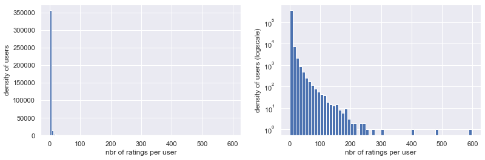

```python
fig, axes = plt.subplots(nrows=1, ncols=2, figsize=(13, 4))
axes[0].hist(data["user"].value_counts(), bins=100)
axes[0].set_xlabel("nbr of ratings per user")
axes[0].set_ylabel("density of users")
axes[1].hist(data["user"].value_counts(), bins=60)
plt.yscale('log', nonposy='clip')
axes[1].set_xlabel("nbr of ratings per user")
axes[1].set_ylabel("density of users (logscale)")
plt.show()
```

```python
# number of values that will be removed
sum(data["user"].value_counts().value_counts()[0:9])
```

```
364889
```

```python
count_users = data['user'].value_counts()
data = data[data['user'].isin(count_users[count_users >= 10].index)]
# number of value we kept
print(data.shape[0])
```

```
303479
```

Now we see that the average rating among all users is centered around 4.0 and has the shape of a normal distribution.

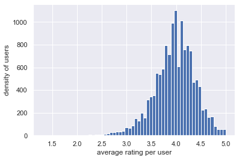

```python
fig = plt.figure()
plt.hist(user_avg_rating, bins=60)
plt.xlabel("average rating per user")
plt.ylabel("density of users")
plt.show()
```

We notice that there is no particular correlation (or at least no trend) between the amont of reviews a user gave and its average ratings, apart from the fact that people who gave a lot of reviews are more "stablized" than people who gave very few ratings. This is actually normal since you have more chances to be at extremes ratings averages when you give only a few ratings.

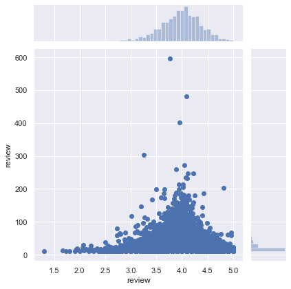

```python
sns.jointplot(user_avg_rating, data.groupby('user')['review'].count())
```

$\Large{\text{The restaurants}}$

Some restaurants like "Le Bouillon Chartier" or "Le Train Bleu" have more than 1000 reviews, which is very valuable, but others like "Kifak" or "Bangkok Bistronomie" have only 1. We will then remove all the restaurants with less than 50 reviews, more or less for the same reasons as the restriction on users, except that here the lost of information is way less than for users, but the gain in term of matrix size is also lower.

```
Le Bouillon Chartier    1932
Le Train Bleu           1066
Léon De Bruxelles        941
La Coupole               819
Dans le Noir ?           669
                        ...
El Barrio                  1
Cru Restaurant             1
Kifak                      1
Pizza Dino                 1
Bangkok Bistronomie        1
Name: restaurant, Length: 7756, dtype: int64
```

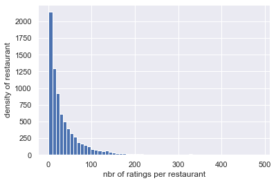

```python
print(data['restaurant'].value_counts())
fig = plt.figure()
plt.hist(data['restaurant'].value_counts()[data['restaurant'].value_counts() < 500], bins=60)
plt.xlabel('nbr of ratings per restaurant')
plt.ylabel('density of restaurant')
plt.show()
```

```python
# number of values that will be removed
sum(data["restaurant"].value_counts().value_counts()[0:49])
```

```
5887
```

```python
count_restaurants = data['restaurant'].value_counts()
data = data[data['restaurant'].isin(count_restaurants[count_restaurants >= 50].index)]
```

When looking at the average ratings for each restaurant, we can see that the density of restaurant per ratings looks like the density of user per ratings, it it centered around 4 and has the shape of a normal distribution

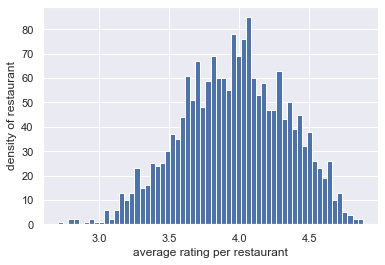

```python
restaurant_avg_rating = data.groupby('restaurant')['review'].mean()
fig = plt.figure()
plt.hist(restaurant_avg_rating, bins=60)
plt.xlabel('average rating per restaurant')
plt.ylabel('density of restaurant')
plt.show()
```

$\LARGE{\text{Recommender system}}$

As describe in the introduction, the goal here will be to predict the ratings that each user would have given to a restaurant, based on the few informations we have. To do this we need first to transform our dataset into a matrix where the rows will be the users, the columns will be the restaurants, and the values will be the ratings of each user to each restaurant:

```python
rating_matrix = data.pivot_table(index='user', columns='restaurant', values='review')
rating_matrix.head()
```

| restaurant user | 0039 Ristorante Italiano | 116 by Pages | 142 Creperie Contemporaine | 16 Haussmann | 20 Eiffel | 3 Pieces Cuisine | 4 Pat | 42 Degres | 58 Tour Eiffel | 6 New York | ... | la table de genevieve | la vache acrobate | le Casse Noix | le Diamant de Paris | le cambodge | le goyavier | le papacionu | o'jules | touch'in paris | À la Bonne Bière |
| --- | --- | --- | --- | --- | --- | --- | --- | --- | --- | --- | --- | --- | --- | --- | --- | --- | --- | --- | --- | --- | --- |
| rachid m | NaN | NaN | NaN | NaN | NaN | NaN | NaN | NaN | NaN | NaN | ... | NaN | NaN | NaN | NaN | NaN | NaN | NaN | NaN | NaN | NaN |
| -Tonio-2706- | NaN | NaN | NaN | NaN | NaN | NaN | NaN | NaN | NaN | NaN | ... | NaN | NaN | NaN | NaN | NaN | NaN | NaN | NaN | NaN | NaN |
| 001guillaumek | NaN | NaN | NaN | NaN | NaN | NaN | NaN | NaN | NaN | NaN | ... | NaN | NaN | NaN | NaN | NaN | NaN | NaN | NaN | NaN | NaN |
| 00essai | NaN | NaN | NaN | NaN | NaN | NaN | NaN | NaN | NaN | NaN | ... | NaN | NaN | NaN | NaN | NaN | NaN | NaN | NaN | NaN | NaN |
| 057719519 | NaN | NaN | NaN | NaN | NaN | NaN | NaN | NaN | NaN | NaN | ... | NaN | NaN | NaN | NaN | NaN | NaN | NaN | NaN | NaN | NaN |

5 rows × 1877 columns

```python
n = rating_matrix.shape[0]
p = rating_matrix.shape[1]
print("Our matrix has dimensions: {0} x {1}".format(n, p))
```

```
Our matrix has dimensions: 13739 x 1877
```

From the display above, we can think that every value of the matrix is missing, but that's not the case, there are still 195355 non-missing values amongst the 25788103 values in total

```python
nb_full = np.count_nonzero(~np.isnan(rating_matrix))
rate_NaN = 1-(nb_full / (n*p))
print("Our matrix contains {:.2f}% of NaN".format(rate_NaN * 100))
print("The matrix contains {0} non-missing values within {1} values in total".format(nb_full, n*p))
```

```
Our matrix contains 99.24% of NaN
The matrix contains 195355 non-missing values within 25788103 values in total
```

$\Large{\text{Dataset separation}}$

Before applying different methods, we need to split the data into a training set and a test set. Both training and test set will be matrices with the same size as the initial matrix, but we will split the data such that we have 20% of the non-missing values in the test set and 80% of the non-missing values in the training set.

```python
from sklearn.model_selection import train_test_split
index_not_nan = np.argwhere(~np.isnan(rating_matrix).values)
idx_train, idx_test = train_test_split(index_not_nan, test_size=0.2)

def extract_train_test(matrix, idx_train, idx_test):
    rating_matrix_train = matrix.copy()
    rating_matrix_test = matrix.copy()
    for id_train in idx_train:
        rating_matrix_test.iloc[id_train[0], id_train[1]] = np.nan
    for id_test in idx_test:
        rating_matrix_train.iloc[id_test[0], id_test[1]] = np.nan

    return rating_matrix_train, rating_matrix_test
```

$\Large{\text{Random approach}}$

Our first approach will be a really easy and naive method, with obviously no good results, but let's do it anyway. We are going to replace any missing value by a random integer between 1 and 5.

```python
# First let's split the dataset into learning and test samples
rating_matrix_train, rating_matrix_test = extract_train_test(rating_matrix, idx_train, idx_test)
```

```python
print("We have: {0} non-missing values for the learning sample\nand {1} non-missing values for the test sample".format(
        np.count_nonzero(~np.isnan(rating_matrix_train)), np.count_nonzero(~np.isnan(rating_matrix_test))))
```

```
We have: 156284 non-missing values for the learning sample
and 39071 non-missing values for the test sample
```

```python
# Let's replace all NaN values in the train matrix by a random number between 1 and 5:
nan_mask = np.isnan(rating_matrix_train.values)
rating_matrix_train.values[nan_mask] = np.random.randint(1, 6, size=np.count_nonzero(nan_mask))
```

```python
# Let's get the accuracy on the predictions on the test sample
test_values = np.array([rating_matrix_test.iloc[x[0],x[1]] for x in idx_test])
predict_values = np.array([rating_matrix_train.iloc[x[0],x[1]] for x in idx_test])

sum_abs = sum(np.nan_to_num(abs(test_values - predict_values)))
sum_square = sum(np.nan_to_num((test_values - predict_values)**2))
n_test_not_nan = sum(~np.isnan(test_values - predict_values))
mae = sum_abs / n_test_not_nan
mse = sum_square / n_test_not_nan
print("MAE(mean absolute error): {0:.3f}\nMSE(mean square error): {1:.3f}".format(mae, mse))
```

```
MAE(mean absolute error): 1.592
MSE(mean square error): 3.968
```

$\Large{\text{Average method}}$

Now we will have a different approach, still very naive, but hopefully we will get better results. We will replace any missing rating from user i given to restaurant j by the average rating of this restaurant over all users. This method is not personalized at all and will not reflect the different behaviors of users. But this is already a good benchmark that we will try to beat later with more customed methods.

```python
# We build again the training and test samples
rating_matrix_train, rating_matrix_test = extract_train_test(rating_matrix, idx_train, idx_test)
```

```python
def replace_by_mean(x):
    avg = np.mean(x)
    for i in range(0,n):
        if np.isnan(x[i]):
            x[i] = avg
    return x
rating_matrix_naive = rating_matrix_train.apply(replace_by_mean)
```

```python
# Let's get the accuracy of the predictions on the test sample
test_values = np.array([rating_matrix_test.iloc[x[0],x[1]] for x in idx_test])
predict_values = np.array([round(rating_matrix_naive.iloc[x[0],x[1]]) for x in idx_test])
```

```python
sum_abs = sum(np.nan_to_num(abs(test_values - predict_values)))
sum_square = sum(np.nan_to_num((test_values - predict_values)**2))
n_test_not_nan = sum(~np.isnan(test_values - predict_values))
mae = sum_abs / n_test_not_nan
mse = sum_square / n_test_not_nan
print("MAE(mean absolute error): {0:.3f}\nMSE(mean square error): {1:.3f}".format(mae, mse))
```

```
MAE(mean absolute error): 0.721
MSE(mean square error): 1.057
```

In the real world obviously the methods above are not one used to build good recommender systems, since they are really not accurate. Two main methods are used in practice, the collaborative filtering method and the content based method. The collaborative filtering method is the one we are going to focus on from now on, and is based only on interactions between users and products (in our case between users and restaurants). We can distinguish two approaches within that method, the memory based apporach and the model based approach. In order to apply the methods to our data, we will use a python library called "surprise" (for Simple Python Recommendation System Engine), which is specially made to apply machine learning algorithms to large sparse matrix like we have. This library is really easy to use and looks a lot like scikit learn (with methods such as gridSearch, or train_test_split for example). Let's start by loading our data into a surprise object:

```python
from surprise import Reader, Dataset
reader = Reader()
data_srp = Dataset.load_from_df(data[['user', 'restaurant', 'review']], reader)
```

Then let's split this data into training and test sample. The split is done in the same way as we did by hand earlier, except that the data is stored in a different way more adapted to achieve our objective.

```python
from surprise.model_selection import train_test_split
train_srp, test_srp = train_test_split(data_srp, test_size=0.20)
```

$\large{\text{Memory based approach}}$

This approach assumes no latent model and uses only information from the user-item interaction to predict new recommendation. The most famous algorithm for this approach is KNN. It can be computed for user-user similarities, or item-item similarities. For user-user (the one we will focus on), it will compute the distances between all users, where the distance is calculated by default as the mean square difference (msd) of ratings over all items (it takes into account only items for which both users gave ratings, meaning that is there is a NaN value in either of them, the rating difference on this item will not be calculated):

$$d^{msd}(u,v) = \frac{1}{\mid J_{uv}\mid}\sum_{j\in J_{uv}}{(r_{uj} - r_{vj})^2} $$

Where $r_{uj}$ is the rating given by user $u$ to restaurant $j$, $r_{vj}$ is the rating given by user $v$ to restaurant $j$ and $J_{uv}$ is the space of restaurant for which both user $u$ and $v$ gave ratings.

The predicted value of rating for user $i$ to restaurant $j$ will then be the average rating given to that restaurant over the $k$ neighbors of $i$.

```python
from surprise import KNNBasic, accuracy

# Here the KNN is train with default parameter k=40, min_k=1 and user-user interactions
knn = KNNBasic(verbose=False)
knn.fit(train_srp)
predictions_knn = knn.test(test_srp)
score_knn_mse = accuracy.mse(predictions_knn)
```

```
MSE: 1.0984
```

Interestingly we get a score worse than our naive method wich gives the average all the time.

By default, the KNN is trained with k=40 (number of neighbors), min_k=1 (minimum of of neighbors to take into account for aggregation, if there are not enough neighbors, the prediction is set to the global mean of all ratings), and the measure of similarities "msd" (mean square difference).

We will do a grid search in order to find the best parameters of the KNN method to fit our data: we will do some cross validation with different values of k, min_k and with two measures of similarities: the "msd" measure and the "cosine" measure, which is defined as:

$$d^{cosine}(u,v) = \frac{\sum\limits_{j\in J_{uv}}{r_{uj}.r_{vj}}}{\sqrt{\sum\limits_{j\in J_{uv}}{r_{uj}^2}}\sqrt{\sum\limits_{j\in J_{uv}}{r_{vj}^2}}} $$

First we will need to separate again our dataset, in the same way as the train_test_split method, but leading to a different type of object which is handled by the GridSearchCV method.

```python
rating_matrix_train, rating_matrix_test = extract_train_test(rating_matrix, idx_train, idx_test)

data_train = pd.DataFrame(rating_matrix_train.to_records())
data_train = pd.melt(data_train, id_vars='user', value_vars=list(data_train.columns[1:]), var_name='restaurant', value_name='review').dropna()
data_train_srp = Dataset.load_from_df(data_train[['user', 'restaurant', 'review']], reader)

data_test = pd.DataFrame(rating_matrix_test.to_records())
data_test = pd.melt(data_test, id_vars='user', value_vars=list(data_test.columns[1:]), var_name='restaurant', value_name='review').dropna()
data_test_srp = Dataset.load_from_df(data_test[['user', 'restaurant', 'review']], reader)
```

We do a grid search on the training set with a cross-validation parameter cv=5 and we display the best parameters and the mean square error: (We have done some pre-search before in order to get reasonable ranges of the parameters)

```python
from surprise.model_selection import GridSearchCV
param_grid = {'k': [80, 100, 120, 140], 'min_k': [5, 7, 9], 'sim_options': {'name': ['msd', 'cosine']}, 'verbose':[False]}
gs_knn = GridSearchCV(KNNBasic, param_grid, measures=['rmse'], cv=5)
gs_knn.fit(data_train_srp)
print("mse: {:.3f}".format(gs_knn.best_score['rmse']**2))
print(gs_knn.best_params['rmse'])
```

```
mse: 1.040
{'k': 140, 'min_k': 7, 'sim_options': {'name': 'cosine', 'user_based': True}, 'verbose': False}
```

Now let's fit the KNN with the best parameters on the whole train set in order to get the accuracy on predictions for the test dataset so that we can compare it to the score of the "average method"

```python
knn = KNNBasic(k=140, min_k=7, sim_options = {'name': 'cosine'}, verbose=False)
knn.fit(train_srp)
predictions_knn = knn.test(test_srp)
score_knn = accuracy.mse(predictions_knn)
```

```
MSE: 1.0431
```

In the end with the KNN method we get a score slightly better than the "average method", but it's not very satisfying. This is probably due to the fact that most of the real ratings are concentrated around the mean (around 4.0) and thus giving the average rating all the time ensure that we are not very far from each actual ratings (especially because the 1.0 or 2.0 ratings are quit rare, which is not that significant when computing the mean square error). Maybe we would need a different measure than the mean square error, for example by giving more weight on the good predictions of 1.0 and 2.0 ratings than the good predictions of 4.0 ratings. I guess we would get better results for the KNN method and worse results for the "average method". Unfortunatly the surprise library doesn't allow us to be free on this part and only propose four different measures of error: the mse (mean square error), the rmse, the mae (mean absolute error) and the fcp (fraction of concordant pairs).

$\large{\text{Model based approach}}$

Model based apporaches, like matrix factorization, are still based on user-item interactions but assume a latent model is supposed to explain these interactions. In matrix factorization, the idea is to find two small-dimensional and dense matrices to represent both users and items in order to reconstruct the initial matrix by computing the dot product of the two.

In other words, we search $A\in M_{n,k}(\mathbb{R})$ and $B\in M_{k,p}(\mathbb{R})$ such that $M = A.B + \epsilon$ where M is our matrix rating. $k$ represents a property in restaurant, for example the fact that it is cheap, and if a restaurant $j$ has that property the value of $b_{k,j}$ will be high. $k$ represents also how much the user values that feature. So if a user $i$ likes going to cheap restaurant, $a_{ik}$ will be high.

So we search: $$(A,B) = \underset{B\in M_{k,p}(\mathbb{R})}{\underset{A\in M_{n,k}(\mathbb{R})}{\mathrm{argmin}}}\sum_{(i,j)\in E}{\left(M_{i,j} - A_iB_j\right)^2} $$

Where $E = \{(i,j)\in\mathbb{R}^{n\times p}$ such that $M_{i,j}\neq nan\}$

($E$ is the space of index where $M$ is full)

Since the vectors of $A$ and $B$ can take any value, and in order to avoid overfitting, we need to add regularization to our loss function, with a penalty coefficient $\lambda$ on the norm $\|A_i\|^2$ and $\|B_j\|^2$.

Hence we want to minimize the expression: $$\underset{A,B}{\mathrm{min}}\ \ \frac{1}{2}\sum_{(i,j)\in E}{\left(M_{i,j} - A_iB_j\right)^2} + \frac{1}{2}\lambda\left(\|A_i\|^2 + \|B_j\|^2\right)$$

But what is done in the surprise library is a bit more subtle than that, because it takes something important that wasn't mentioned so far: the bias.

In fact, the two matrices we want to find here are supposed to explain how the interactions between users and restaurants work and how they lead to produce the rating values. However, much of the real variation in rating values is due to particular effects amongst users or restaurant, and are independant of these variations. These effects are called biases. For example, some users tend to give higher rates than other for the same level of satisfaction, which will result in differences of ratings which are not significant regarding our models and objectives. In order to take this effect into account, we model the bias by approaching $M_{ij}$ by $A_i.B_j + \mu + \beta_i + \beta_j$, where $\mu$ is the overall rating average (it can be computed directly from the data), $\beta_i$ is the bias of user $i$ and $\beta_j$ is the bias of restaurant $j$.

The expression we want to minimize becomes now: $$\underset{A,B,\beta}{\mathrm{min}}\ \ \frac{1}{2}\sum_{(i,j)\in E}{\left(M_{i,j} - A_iB_j\right)^2} + \frac{1}{2}\lambda\left(\|A_i\|^2 + \|B_j\|^2\right)$$ with $A\in M_{n,k}(\mathbb{R})$, $B\in M_{k,p}(\mathbb{R})$ and $\beta\in\mathbb{R}^{n\times p}$

It can be done simply with a stochastic gradient descent (we are not going to write the details but the calculation of the gradient is straightforward). This is what is done with the library surprise and the method SVD, which we are going to apply now.

```python
from surprise import SVD
svd = SVD()
svd.fit(train_srp)
predictions_svd = svd.test(test_srp)
score_svd = accuracy.mse(predictions_svd)
```

```
MSE: 0.9797
```

This matrix factorization method was done with the default parameters of the surprise method, which are:

- n_epochs = 20 (the number of times the stochastic gradient descent is performed on over all the ratings)
- lr_all = 0.005 (the learning rate of the stochastic gradient descent)
- reg_all = 0.02 (the regularization coefficient)

Let's compute a grid search once again in order to find the best parameters:

```python
param_grid = {'n_epochs': [10, 20, 30], 'lr_all': [0.001, 0.005, 0.01],
              'reg_all': [0.1, 0.2, 0.5]}

gs_svd = GridSearchCV(SVD, param_grid, measures=['rmse'], cv=5)
gs_svd.fit(data_train_srp)
print("mse: {:.3f}".format(gs_svd.best_score['rmse']**2))
print(gs_svd.best_params['rmse'])
```

```
mse: 0.933
{'n_epochs': 20, 'lr_all': 0.005, 'reg_all': 0.2}
```

Once again let's fit the method on the training set with the best parameters in order to get the predictions score on the test set, and be able to compare it with the previous methods:

```python
svd = SVD(n_epochs=20, lr_all=0.005, reg_all=0.2)
svd.fit(train_srp)
predictions_svd = svd.test(test_srp)
score_svd = accuracy.mse(predictions_svd)
```

```
MSE: 0.9592
```

We can be happy about this score which is really better than all the methods above. This is probably due to the fact that the SVD model is more complex and manage to get the best from the sparse matrix.

$\huge{Conclusion}$

In order to answer to our initial question (where am I going to eat tonight ?), we will use the method with the best score computed on the test set, which is the SVD method.

First we will create a new user representing myself and we will give ratings to restaurants where I have been to eat in Paris, some that I liked and some that I didn't.

```python
print(data.shape)
```

```
(201038, 3)
```

```python
my_rating_dict_list = [{'user':'jfoenet06', 'restaurant':'Le Bistrot des Halles', 'review':5},
                  {'user':'jfoenet06', 'restaurant':'Au Pied de Cochon', 'review':5},
                  {'user':'jfoenet06', 'restaurant':'KONG', 'review':2},
                  {'user':'jfoenet06', 'restaurant':'Chez Denise', 'review':4},
                  {'user':'jfoenet06', 'restaurant':'Cafe Daguerre', 'review':1},
                  {'user':'jfoenet06', 'restaurant':'La Maison Péret', 'review':3},
                  {'user':'jfoenet06', 'restaurant':'L\'Ardoise', 'review':5},
                  {'user':'jfoenet06', 'restaurant':'Augustin Bistrot', 'review':5},
                  {'user':'jfoenet06', 'restaurant':'Le Sirocco', 'review':4},
                  {'user':'jfoenet06', 'restaurant':'Au Chien Qui Fume', 'review':4},
                  {'user':'jfoenet06', 'restaurant':'L\'Alsacien', 'review':4},
                  {'user':'jfoenet06', 'restaurant':'Creperie de Pontivy', 'review':3}]

for elt in my_rating_dict_list:
    data = data.append(elt, ignore_index=True)

print(data.shape)
```

```
(201050, 3)
```

```python
reader = Reader()
data_srp = Dataset.load_from_df(data[['user', 'restaurant', 'review']], reader)
full_dataset = data_srp.build_full_trainset()
```

```python
svd = SVD(n_epochs=20, lr_all=0.005, reg_all=0.2, verbose=False)
svd.fit(full_dataset)
```

```
<surprise.prediction_algorithms.matrix_factorization.SVD at 0x1aa0f92f10>
```

```python
list_pred_dict = [svd.predict(uid='jfoenet', iid=rest) for rest in data["restaurant"].unique()]
list_pred = [svd.predict(uid='jfoenet', iid=rest).est for rest in data["restaurant"].unique()]
winner_restaurant = list_pred_dict[list_pred.index(max(list_pred))].iid
print(winner_restaurant)
```

```
Alliance
```